# Presidential Campaign Donations

I will be looking at presidential campaign donations for the state of Ohio for the 2016 presidential election. This was the most contentious election that I can remember, and I am interested in finding out more about where donations from within my state went, and if they compare to the overall election.

Initially I had an issue trying to import the file from CSV. I received an error stating there could not be duplicate row.names. Found a post on OverStack.com where someone else had a similar issue. One of the suggestions for fixing it was to check the original CSV file to see if a comma had been ommitted from the end of the header row. Checked my file, and found this was the case. Added the comma and reran the command to enter the data. https://stackoverflow.com/questions/8854046/duplicate-row-names-are-not-allowed-error-in-r-programming

```
[1] 167259     19
```

```
'data.frame':   167259 obs. of  19 variables:
 $ cmte_id          : Factor w/ 24 levels "C00458844","C00500587",..: 15 15 15 15 15 6 12 7 6 7 ...
 $ cand_id          : Factor w/ 24 levels "P00003392","P20002671",..: 23 23 23 23 23 1 15 12 1 12 ...
 $ cand_nm          : Factor w/ 24 levels "Bush, Jeb","Carson, Benjamin S.",..: 22 22 22 22 22 4 14 19 4 19 ...
 $ contbr_nm        : Factor w/ 44968 levels "'CALLAHAN, PAMELA",..: 35963 35967 35975 33864 33867 17322 8617 16139 36641 25134 ...
 $ contbr_city      : Factor w/ 1360 levels " BATAVIA","45320",..: 244 708 248 231 193 274 589 274 596 231 ...
 $ contbr_st        : Factor w/ 1 level "OH": 1 1 1 1 1 1 1 1 1 1 ...
 $ contbr_zip       : int  45315 44060 44106 45208 44721 432141210 441071232 432022420 450365038 45249 ...
 $ contbr_employer  : Factor w/ 13494 levels "","-","(SCHOOL)",..: 5791 9973 5791 1283 10550 5791 3169 8464 9973 10547 ...
 $ contbr_occupation: Factor w/ 6691 levels "","-"," CERTIFIED REGISTERED NURSE ANESTHETIS",..: 2889 5134 2889 3503 5465 2889 3209 3884 6054 403 ...
 $ contb_receipt_amt: num  97.1 53.5 69.4 88.4 -80 ...
 $ contb_receipt_dt : Date, format: "2016-09-23" "2016-09-01" ...
 $ receipt_desc     : Factor w/ 25 levels ""," SEE REATTRIBUTION",..: 1 1 1 1 1 1 1 1 1 1 ...
 $ memo_cd          : Factor w/ 2 levels "","X": 2 2 2 2 2 2 1 1 2 1 ...
 $ memo_text        : Factor w/ 89 levels ""," SEE REATTRIBUTION",..: 1 1 1 1 1 19 1 10 19 10 ...
 $ form_tp          : Factor w/ 3 levels "SA17A","SA18",..: 2 2 2 2 2 2 1 1 2 1 ...
 $ file_num         : int  1146165 1146165 1146165 1146165 1146165 1091718 1144564 1077404 1091718 1077404 ...
 $ tran_id          : Factor w/ 166816 levels "A0000FD2A304E432AAD5",..: 108798 118153 112319 108928 120998 54281 166784 144656 54504 144411 ...
 $ election_tp      : Factor w/ 4 levels "","G2016","O2016",..: 2 2 2 2 2 4 4 4 4 4 ...
 $ X                : logi  NA NA NA NA NA NA ...
```

```
      cmte_id           cand_id                           cand_nm
 C00575795:71232   P00003392:71232   Clinton, Hillary Rodham  :71232
 C00577130:34686   P60007168:34686   Sanders, Bernard         :34686
 C00580100:26873   P80001571:26873   Trump, Donald J.         :26873
 C00574624:16406   P60006111:16406   Cruz, Rafael Edward 'Ted':16406
 C00573519: 7937   P60005915: 7937   Carson, Benjamin S.      : 7937
 C00581876: 4824   P60003670: 4824   Kasich, John R.          : 4824
 (Other)  : 5301   (Other)  : 5301   (Other)                  : 5301
                  contbr_nm          contbr_city     contbr_st
 STOWE, JANICE         :   277   COLUMBUS  : 17469   OH:167259
 MISSLER, ANDREW J. MR.:   203   CINCINNATI: 15877
 BRIONES, BERTA        :   179   CLEVELAND :  5821
 MOESER, DONALD        :   176   DAYTON    :  4716
 CUMMINGS, JOHN        :   142   TOLEDO    :  3316
 SCHEEL, PATRICK       :   133   AKRON     :  3239
 (Other)               :166149   (Other)   :116821
   contbr_zip                     contbr_employer              contbr_occupation
 Min.   :       10   RETIRED              :27810   RETIRED              :44150
 1st Qu.:430829335   N/A                  :22441   NOT EMPLOYED         :10397
 Median :440741909   SELF-EMPLOYED        : 8590   INFORMATION REQUESTED: 8451
 Mean   :362553798   INFORMATION REQUESTED: 8512   ATTORNEY             : 3332
 3rd Qu.:450051586   NONE                 : 7639   HOMEMAKER            : 3245
 Max.   :458969665   (Other)              :92136   (Other)              :97662
 NA's   :3           NA's                 :  131   NA's                 :   22
 contb_receipt_amt  contb_receipt_dt                         receipt_desc
 Min.   :-10800.0   Min.   :2014-07-17                             :165233
 1st Qu.:    16.0   1st Qu.:2016-02-29   Refund                    :   933
 Median :    29.0   Median :2016-06-04   REDESIGNATION FROM PRIMARY:   211
 Mean   :   119.3   Mean   :2016-05-19   REDESIGNATION TO GENERAL  :   210
 3rd Qu.:    80.0   3rd Qu.:2016-08-31   REATTRIBUTION TO SPOUSE   :   114
 Max.   : 29100.0   Max.   :2016-12-31   REATTRIBUTION FROM SPOUSE :   112
                                         (Other)                   :   446
 memo_cd                                  memo_text       form_tp
  :128435                                      :117372   SA17A:128696
 X: 38824   * EARMARKED CONTRIBUTION: SEE BELOW: 33677   SA18 : 37630
            * HILLARY VICTORY FUND             : 14396   SB28A:   933
            EARMARKED FROM MAKE DC LISTEN      :   282
            *BEST EFFORTS UPDATE               :   246
            REDESIGNATION FROM PRIMARY         :   211
            (Other)                            :  1075
    file_num                       tran_id       election_tp       X
 Min.   :1003942   A80E77D0E713E417AA88:     3        :   393   Mode:logical
 1st Qu.:1077665   C11887628           :     3   G2016: 59160   NA's:167259
 Median :1099613   C10225661           :     2   O2016:    20
 Mean   :1101253   C10228611           :     2   P2016:107686
 3rd Qu.:1133832   C10230213           :     2
 Max.   :1146285   C10234145           :     2
                   (Other)             :167245
```

Now that I have a sense of the overall data, I want to see more specifics about a few of the variables.

# Univariate Plots

### Candidates

Let’s start by looking at who was getting these donations.

```
                Bush, Jeb       Carson, Benjamin S.  Christie, Christopher J.
                      297                      7937                        22
  Clinton, Hillary Rodham Cruz, Rafael Edward 'Ted'            Fiorina, Carly
                    71232                     16406                       625
       Graham, Lindsey O.            Huckabee, Mike             Jindal, Bobby
                       36                       152                         9
            Johnson, Gary           Kasich, John R.          Lessig, Lawrence
                      316                      4824                        22
           McMullin, Evan   O'Malley, Martin Joseph         Pataki, George E.
                       36                        27                         2
               Paul, Rand    Perry, James R. (Rick)              Rubio, Marco
                      790                        10                      2634
         Sanders, Bernard      Santorum, Richard J.               Stein, Jill
                    34686                        79                       130
         Trump, Donald J.             Walker, Scott     Webb, James Henry Jr.
                    26873                       106                         8
```

24 candidates received some donations for their presidential campaigns from individuals in the state of Ohio. 4 of those had 10 or less donations, and another 6 had 100 donations or less. These numbers pale in comparison to the 71,000 that Hillary Clinton received. It’s also interesting that Bernie Sanders had more donations than Donald Trump, even though he did not make it past the primaries.

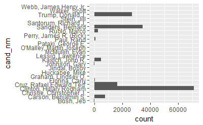

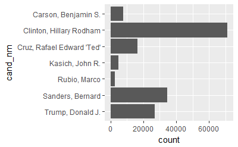

Narrowing our list of candidates down to just the top 7 makes it much easier to see the differences in the contributions they received.

### City

Now let’s look at where the donations came from.

```
         COLUMBUS        CINCINNATI         CLEVELAND            DAYTON
            17469             15877              5821              4716
           TOLEDO             AKRON       WESTERVILLE            DUBLIN
             3316              3239              2347              2139
   SHAKER HEIGHTS          LAKEWOOD            CANTON        YOUNGSTOWN
             1724              1677              1480              1390
CLEVELAND HEIGHTS      WEST CHESTER     CHAGRIN FALLS            POWELL
             1385              1362              1295              1250
      BEAVERCREEK             MASON       SPRINGFIELD          HAMILTON
             1167              1150              1049              1037
           ATHENS       WORTHINGTON          HILLIARD              KENT
             1034               969               918               908
          (Other)
            92540
```

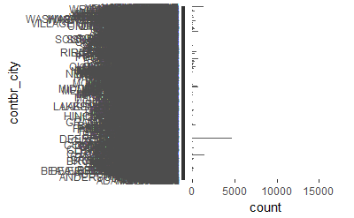

Looking at all of the cities in the state is nearly impossible in a graph like this, as there are simply too many cities. Let’s take a closer look at the cities that had over 2000 donations.

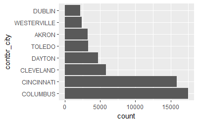

As expected, the three largest cities in the state lead the way. However, I am surprised to see Cleveland so far behind the other two in terms of number of donations. As of the 2010 census, Cleveland was the second largest city in the state behind Columbus. This could be something to look into further during later investigations.

### Occupations

Next let’s take a look at the occupations of our contributors.

```
                               RETIRED                           NOT EMPLOYED
                                 44150                                  10397
                 INFORMATION REQUESTED                               ATTORNEY
                                  8451                                   3332
                             HOMEMAKER                              PHYSICIAN
                                  3245                                   3044
                               TEACHER                              PROFESSOR
                                  3021                                   2532
                              ENGINEER                                  SALES
                                  1654                                   1631
                            CONSULTANT INFORMATION REQUESTED PER BEST EFFORTS
                                  1416                                   1382
                               MANAGER                                  OWNER
                                  1329                                   1092
                             PRESIDENT
                                  1026                                    992
                      REGISTERED NURSE                             ACCOUNTANT
                                   915                                    840
                                   CEO                         BUSINESS OWNER
                                   749                                    726
                               STUDENT                                     RN
                                   716                                    705
                                LAWYER                                (Other)
                                   627                                  73265
                                  NA's
                                    22
```

There is a wide variety when it comes to the occupations listed, and there appears to be quite a bit of overlap. Looking at just the top 25 categories, we can see one entry for RN’s and another for Registered Nurses. There are also separate entries for Owner and Business Owner. The top two categories are the most surprising to me though. I’m not surprised to see a lot of donations from retired individuals, but the amount of donations they gave is surprising to me. I’m also very surprised by the over 10,000 donations from people that are not employed. Those two numbers will be worth looking into.

### Contribution Size

Now that we have a better idea of where the donations are coming from, let’s take a look at the size of the donations.

```
    Min.  1st Qu.   Median     Mean  3rd Qu.     Max.
-10800.0     16.0     29.0    119.3     80.0  29100.0
```

The bulk of the donations range from $16 up to $80. I’m a little surprised to see a donation of -$10,800 as well.

```
   Mode   FALSE    TRUE
logical  165216    2043
```

It appears there are quite a few negative contributions, but they account for less than 2% of the total donations.

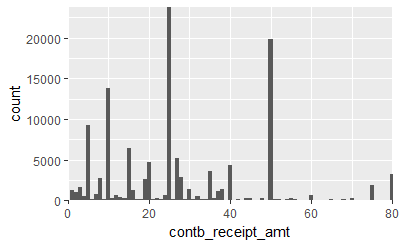

This data shows the most common donations are $25 and $50

Now let’s take a look at those negative donations.

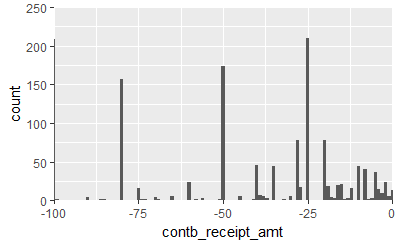

What about those large donations? Let’s take a look at that top 25% of donations.

```
   Min. 1st Qu.  Median    Mean 3rd Qu.    Max.
   80.2   100.0   165.4   421.0   291.8 29100.0
```

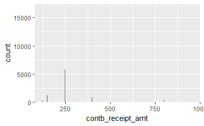

I focused my graph on donations between $80 and $1000 as it seems there are a very limited number of donations above that level. These higher donations show a similar pattern with large numbers of donations at very specific dollar amounts.

```
   Min. 1st Qu.  Median    Mean 3rd Qu.    Max.
   1001    2500    2700    2567    2700   29100
```

### Dates

Let’s take a look at the dates donations were made and see how those line up with the date of Ohio’s primary and the general election.

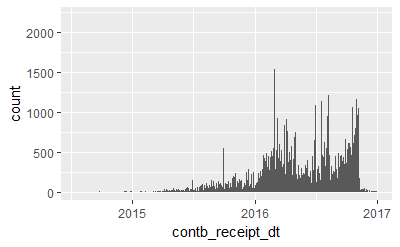

There are some donations to the campaigns as early as 2014. There are also a few peaks in donations throughout 2016, with a sharp dropoff towards the end of the year. Let’s zoom in and focus on just the donations in 2016.

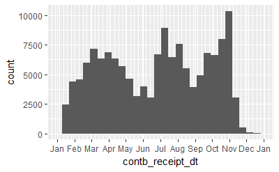

Looking at this breakdown we can see three times where there were bumps in donations. The first in March coincides with the state primary. The second in July matches up with the major party conventions. The third, and largest bump, is just before the election, with donations dropping off almost completely after the election took place.

# Univariate Analysis

So far I’ve found a few interesting points, and a lot of data that makes sense given the nature of political campaigns. There were over 160,000 campaign donations that are included in this data set.

### Main Factors

The main factors in this data that I will be focusing on are the candidates and the amounts they received. I am looking to see if these trends line up with the overall vote in the general and primary elections in the state.

### Other Factors

I am also hoping to look at the city where donors live and their occupations to see if there are trends in political leanings based on career and location.

# Bivariate and Multivariate Plots

### Contribution Amounts by Candidate

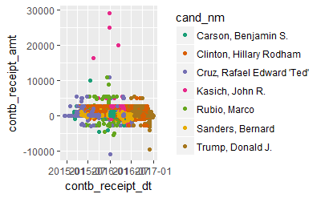

Ted Cruz seems to have been the early favorite in Ohio, getting donations as far back as 2014. Let’s focus our graph to only look at donations made during the 2016 calendar year, as this is the time period when the campaigns would have been in full swing.

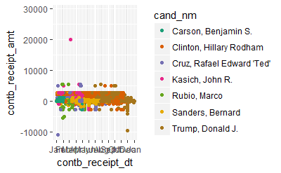

With the exception of a few outliers, most of the contributions appear to fall within a very specific range. Limiting the max amount of donations we are looking at may help give us some more information here.

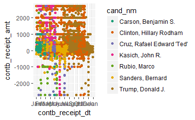

There are definite bands of donations at specific dollar amounts. It’s interesting to see how the support of individual candidates dropped off at specific times. It’s also surprising to see the amount of negative donations, which most likely are refunds, on specific days. More research would need to be done explaining what these negative donations are, and why they are given. Now let’s look one more time at this data and focus just on the positive donations under $500.

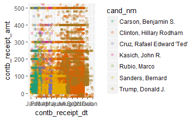

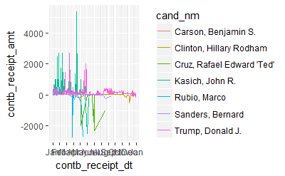

Looking at median contribution amount for each candidate over the year, gives us a lot of variation, and some wide swings from positive to negative, that line up with dates we noticed in our previous graphs. Narrowing our focus to the last few months of the year, will help focus the data on the end of the race when it was down to just two major candidates.

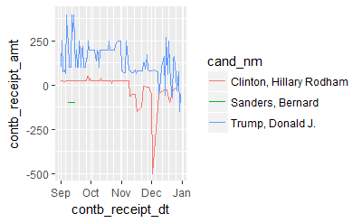

Looking at the time period from September 1 through December 31 let’s us focus on Clinton and Trump. During this stretch, Hillary’s median contribution amount was much lower than Donald’s. It’s also surprising to see how many negative contributions occurred at the end of November and into December.

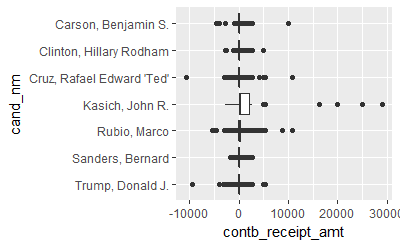

There is a lot going on in this plot. John Kasich seems to be be the winner with individual contributions, collecting 4 that were each over $15,000. Ted Cruz issued the biggest refund, which appears to match the biggest contribution he collected.

Let’s narrow our graph down to focus on the more average donations.

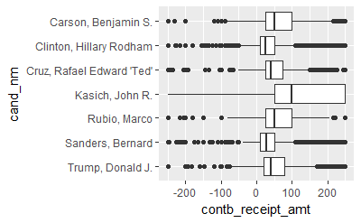

Now that we have a better view of the actual boxes, we can see just how big an impact those big donations had on John Kasich’s overall numbers. It’s also interesting to see how similar the quantiles appear for Hillary Clinton and Bernie Sanders.

```r
by_cand <- subset(ohio, cand_nm %in% top_cand) %>% group_by(cand_nm)
summarise(by_cand, mean(contb_receipt_amt))
```

| cand_nm | mean(contb_receipt_amt) |
| --- | --- |
| Carson, Benjamin S. | 89.19649 |
| Clinton, Hillary Rodham | 94.34276 |
| Cruz, Rafael Edward 'Ted' | 76.63089 |
| Kasich, John R. | 922.56210 |
| Rubio, Marco | 300.01107 |
| Sanders, Bernard | 40.25986 |
| Trump, Donald J. | 147.77014 |

### Total Money Per Candidate

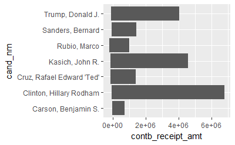

This shows the total amount of money received in contributions. Hillary Clinton is the clear winner here, which isn’t too surprising since she had more than double the number of contributions of any of the other candidates. However, Bernie Sanders had the second highest number of contributions, but is 4th in terms of total money. This shows that Bernie probably had many more low dollar donations compared to the other candidates.

It’s also interesting to see that John Kasich outearned Donald Trump in spite of the fact that he was out of the race shortly after the Ohio primary. This may have something to do with him running a national campaign but being the governor of Ohio. It would be interesting to see how his total campaign contributions compare to his Ohio numbers.

### Contributions by City

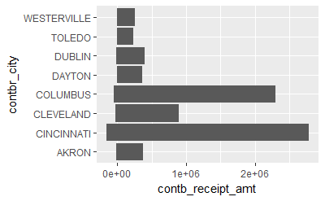

Earlier we saw that Columbus was clearly ahead of the other cities in regards to the number of donations given, however, when we look at the total amount of money being donated, Cincinnati is the clear winner.

### Contribution Amount Per Candidate by City

Now let’s take a look at how the contributions break down by city for each of our top candidates.

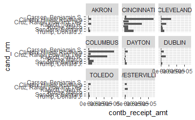

This shows a very interesting trend in the data, as the big cities tend to give more money to Hillary Clinton, who is a democrat, while the affluent suburbs, like Dublin and Westerville gave more money to John Kasich and Donald Trump who are republicans.

To look into this a little more in depth, I am going to look specifically at Columbus and it’s suburbs to see if this trend was coincidental or true across more than just these two cities.

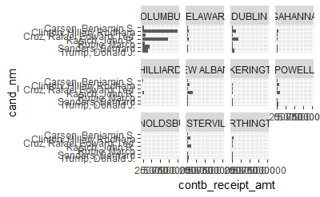

The trend does appear to hold true when taking the majority of suburbs into account, at least for this one major metropolitan area. Only a handful of the suburbs show more money going to the two democratic candidates, while the majority show more money going to republican candidates.

### Contribution Amount per Candidate by Occupation

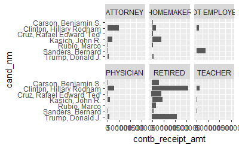

The donations for our top 6 occupations show some interesting trends. Retired individuals seem to be pretty mixed. Homemakers seem to have supported the republican candidates more, while the professional occupations supported Hillary Clinton and the unemployed supported Bernie Sanders. The results from the retired and unemployed individuals are the most surprising to me, so let’s narrow our focus on those two categories.

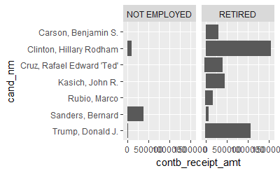

The retired individuals contributed to each of the top 7 candidates in the state. The candidate they supported financially the least is the same candidate that received the bulk of the financial support from the unemployed contributors. This is likely due to the political leanings of Bernie Sanders. The top two candidates the retired individuals contributed to were Trump and Clinton. This makes me wonder if the bulk of these contributions were made before or after the primaries, as these are the two that ran against each other in the general election.

### Contributions by Date for Retired Individuals

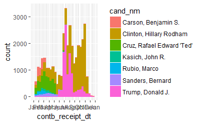

As I suspected, the bulk of the donations for our retired individuals came after the primaries had concluded. Initially most of the contributions after those primaries appear to have gone to Trump, but by late August, had switched to Clinton.

Just for sake of comparison, let’s look at when the unemployed individuals made their donations.

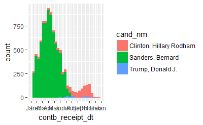

This data for the unemployed individuals makes sense based on who they supported. Bernie Sanders lost the primary, so their financial support appears to have really dropped off after he was officially out of the race.

# Bivariate Analysis

We have explored trends in campaign donations looking at a variety of factors that may help explain the general election results in Ohio from the 2016 presidential election.

### Main Factors

The total amount of money contributed to these candidates lines up exactly with the primary election for the state. Kasich was the top money making republican candidate, and won the republican primary. Clinton was the top money making democrat, and won the democratic primary. However, Trump won the general election in the state, and did not bring in the most amount of money. Looking at the timing of contributions though, it appears that Trump gained ground on Clinton at the very end of the election season, which would line up with his victory in the state.

### Other Factors

Looking at city and occupations provided some interesting insight into the election as well. There appear to be definite trends in political leanings for large cities and suburbs. The early support for Sanders from the unemployed individuals may have also played a large part in the election if those individuals did not have motivation to go out and vote since their candidate was not in the running.

# Final Plots

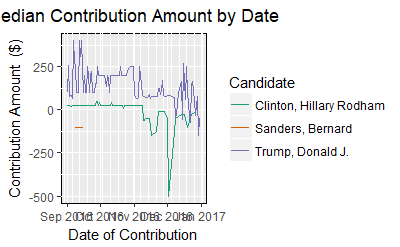

This graph is looking at the median contribution amount per day for the last few months of the election, and the month immediately following the election. This shows a trend where Trump supporters appear to be giving larger contributions than Clinton supporters. This shows that Trump supporters were likely more enthusiastic about their candidate and more likely to go out and vote on election day.

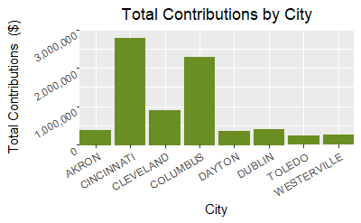

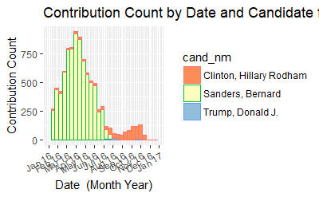

The unemployed category was the second largest group of donors, based on number of donations. This graph shows us when those donations were made, and who they were made to. Early in the year, there were high numbers of contributions, and most were being made to Sanders. After early June, those numbers dropped significantly. While they did rebound slightly, showing increased support for Clinton, they did not reach nearly the levels that Sanders had early in the year. The lack of support for the eventual democratic candidate may signal a lack of enthusiasm that could have helped contribute to lower voter turnout.

# Summary

The 2016 Presidential Election will likely remain one of the most surprising results in any presidential election for quite some time. At the beginning of election day, Clinton was getting ready to give her acceptance speech, and by the end of the day Trump had shocked the world. Looking at the data for campaign contributions from the state of Ohio show some trends that match the national picture, but also may help explain the eventual vote for Ohio going to Trump. By the end of the election Trump was getting larger donations on average compared to Clinton, this could indicate a more enthusiastic voting base, which usually results in higher voter turnout. The democratic primary also seems to have somewhat fractured the democratic base in the state. The donations coming in from unemployed individuals went to Sanders at an extremely high rate, and once he was out of the race, those donations dropped considerably. This could indicate that those voters who supported Sanders were not necessarily excited about Clinton being the nominee and that lack of excitement could have helped contribute to lower voter turnout for democrats.

Again, this was the the most surprising election of my lifetime, and likely will stay that way. Nobody expected the outcome, except maybe Trump himself. These factors we have examined do not show direct correlations that could explain the election results, but by focusing on the end of the race, they may help show the varying levels of voter engagement that could have been enough to influence the eventual outcome in the state.

# Resources

https://groups.google.com/forum/#!topic/ggplot2/AfTB5ijyUIE, quick reference sheet for polishing graphs and charts using ggplot2

https://stackoverflow.com/questions/8854046/duplicate-row-names-are-not-allowed-error-in-r-programming, forum post covering the issue with duplicate row names I initially observed when attempting to read in my CSV file.